# Optimal Treatment Analysis

## Outcome Variable

**Outcome Variable:** whz

## Predictor Variables

**Intervention Variable:** exclfeed3

**Adjustment Set:**

- arm
- sex
- W_mage
- meducyrs
- feducyrs
- hhwealth_quart
- hfoodsec
- W_mhtcm
- vagbrth
- W_gagebrth
- W_birthwt
- W_birthlen
- W_nrooms
- W_nchldlt5
- month
- brthmon
- W_parity
- impfloor
- impsan
- safeh20
- delta_W_mage
- delta_meducyrs
- delta_feducyrs
- delta_hhwealth_quart
- delta_hfoodsec
- delta_W_mhtcm
- delta_vagbrth
- delta_W_gagebrth
- delta_W_birthwt
- delta_W_birthlen
- delta_W_nrooms
- delta_W_nchldlt5
- delta_month
- delta_brthmon
- delta_W_parity
- delta_impfloor
- delta_impsan
- delta_safeh20

## Stratifying Variables

The analysis was stratified on these variable(s):

- agecat
- studyid
- country

## Data Summary

| agecat | studyid | country | exclfeed3 | n_cell | n |
| --- | --- | --- | --- | --- | --- |
| Birth | ki0047075b-MAL-ED | BANGLADESH | 1 | 164 | 227 |
| Birth | ki0047075b-MAL-ED | BANGLADESH | 0 | 63 | 227 |
| Birth | ki0047075b-MAL-ED | BRAZIL | 1 | 65 | 177 |
| Birth | ki0047075b-MAL-ED | BRAZIL | 0 | 112 | 177 |
| Birth | ki0047075b-MAL-ED | INDIA | 1 | 121 | 193 |
| Birth | ki0047075b-MAL-ED | INDIA | 0 | 72 | 193 |
| Birth | ki0047075b-MAL-ED | NEPAL | 1 | 60 | 166 |
| Birth | ki0047075b-MAL-ED | NEPAL | 0 | 106 | 166 |
| Birth | ki0047075b-MAL-ED | PERU | 1 | 64 | 265 |
| Birth | ki0047075b-MAL-ED | PERU | 0 | 201 | 265 |
| Birth | ki0047075b-MAL-ED | SOUTH AFRICA | 1 | 32 | 231 |
| Birth | ki0047075b-MAL-ED | SOUTH AFRICA | 0 | 199 | 231 |
| Birth | ki0047075b-MAL-ED | TANZANIA, UNITED REPUBLIC OF | 1 | 38 | 114 |
| Birth | ki0047075b-MAL-ED | TANZANIA, UNITED REPUBLIC OF | 0 | 76 | 114 |
| Birth | ki1000108-CMC-V-BCS-2002 | INDIA | 1 | 4 | 4 |
| Birth | ki1000108-CMC-V-BCS-2002 | INDIA | 0 | 0 | 4 |
| Birth | ki1000108-IRC | INDIA | 1 | 0 | 9 |
| Birth | ki1000108-IRC | INDIA | 0 | 9 | 9 |
| Birth | ki1000109-EE | PAKISTAN | 1 | 1 | 1 |
| Birth | ki1000109-EE | PAKISTAN | 0 | 0 | 1 |
| Birth | ki1000304b-SAS-CompFeed | INDIA | 1 | 45 | 47 |
| Birth | ki1000304b-SAS-CompFeed | INDIA | 0 | 2 | 47 |
| Birth | ki1101329-Keneba | GAMBIA | 1 | 1150 | 1305 |
| Birth | ki1101329-Keneba | GAMBIA | 0 | 155 | 1305 |
| Birth | kiGH5241-JiVitA-3 | BANGLADESH | 1 | 13731 | 15136 |
| Birth | kiGH5241-JiVitA-3 | BANGLADESH | 0 | 1405 | 15136 |
| Birth | kiGH5241-JiVitA-4 | BANGLADESH | 1 | 28 | 31 |
| Birth | kiGH5241-JiVitA-4 | BANGLADESH | 0 | 3 | 31 |
| 6 months | ki0047075b-MAL-ED | BANGLADESH | 1 | 172 | 237 |
| 6 months | ki0047075b-MAL-ED | BANGLADESH | 0 | 65 | 237 |

[output cut: 58 more lines]

The following strata were considered:

- agecat: 24 months, studyid: ki0047075b-MAL-ED, country: BANGLADESH
- agecat: 24 months, studyid: ki0047075b-MAL-ED, country: BRAZIL
- agecat: 24 months, studyid: ki0047075b-MAL-ED, country: INDIA
- agecat: 24 months, studyid: ki0047075b-MAL-ED, country: NEPAL
- agecat: 24 months, studyid: ki0047075b-MAL-ED, country: PERU
- agecat: 24 months, studyid: ki0047075b-MAL-ED, country: SOUTH AFRICA
- agecat: 24 months, studyid: ki0047075b-MAL-ED, country: TANZANIA, UNITED REPUBLIC OF
- agecat: 24 months, studyid: ki1000108-CMC-V-BCS-2002, country: INDIA
- agecat: 24 months, studyid: ki1000108-IRC, country: INDIA
- agecat: 24 months, studyid: ki1017093b-PROVIDE, country: BANGLADESH
- agecat: 24 months, studyid: ki1101329-Keneba, country: GAMBIA
- agecat: 24 months, studyid: ki1113344-GMS-Nepal, country: NEPAL
- agecat: 24 months, studyid: kiGH5241-JiVitA-3, country: BANGLADESH
- agecat: 24 months, studyid: kiGH5241-JiVitA-4, country: BANGLADESH
- agecat: 6 months, studyid: ki0047075b-MAL-ED, country: BANGLADESH
- agecat: 6 months, studyid: ki0047075b-MAL-ED, country: BRAZIL
- agecat: 6 months, studyid: ki0047075b-MAL-ED, country: INDIA
- agecat: 6 months, studyid: ki0047075b-MAL-ED, country: NEPAL
- agecat: 6 months, studyid: ki0047075b-MAL-ED, country: PERU
- agecat: 6 months, studyid: ki0047075b-MAL-ED, country: SOUTH AFRICA
- agecat: 6 months, studyid: ki0047075b-MAL-ED, country: TANZANIA, UNITED REPUBLIC OF
- agecat: 6 months, studyid: ki1000108-CMC-V-BCS-2002, country: INDIA
- agecat: 6 months, studyid: ki1000108-IRC, country: INDIA
- agecat: 6 months, studyid: ki1000109-EE, country: PAKISTAN
- agecat: 6 months, studyid: ki1000304b-SAS-CompFeed, country: INDIA
- agecat: 6 months, studyid: ki1017093b-PROVIDE, country: BANGLADESH
- agecat: 6 months, studyid: ki1101329-Keneba, country: GAMBIA
- agecat: 6 months, studyid: ki1113344-GMS-Nepal, country: NEPAL
- agecat: 6 months, studyid: kiGH5241-JiVitA-3, country: BANGLADESH
- agecat: 6 months, studyid: kiGH5241-JiVitA-4, country: BANGLADESH
- agecat: Birth, studyid: ki0047075b-MAL-ED, country: BANGLADESH
- agecat: Birth, studyid: ki0047075b-MAL-ED, country: BRAZIL
- agecat: Birth, studyid: ki0047075b-MAL-ED, country: INDIA
- agecat: Birth, studyid: ki0047075b-MAL-ED, country: NEPAL
- agecat: Birth, studyid: ki0047075b-MAL-ED, country: PERU
- agecat: Birth, studyid: ki0047075b-MAL-ED, country: SOUTH AFRICA
- agecat: Birth, studyid: ki0047075b-MAL-ED, country: TANZANIA, UNITED REPUBLIC OF
- agecat: Birth, studyid: ki1000108-CMC-V-BCS-2002, country: INDIA
- agecat: Birth, studyid: ki1000108-IRC, country: INDIA
- agecat: Birth, studyid: ki1000109-EE, country: PAKISTAN
- agecat: Birth, studyid: ki1000304b-SAS-CompFeed, country: INDIA
- agecat: Birth, studyid: ki1101329-Keneba, country: GAMBIA
- agecat: Birth, studyid: kiGH5241-JiVitA-3, country: BANGLADESH
- agecat: Birth, studyid: kiGH5241-JiVitA-4, country: BANGLADESH

### Dropped Strata

Some strata were dropped due to rare outcomes:

- agecat: Birth, studyid: ki1000108-CMC-V-BCS-2002, country: INDIA
- agecat: Birth, studyid: ki1000108-IRC, country: INDIA
- agecat: Birth, studyid: ki1000109-EE, country: PAKISTAN
- agecat: Birth, studyid: ki1000304b-SAS-CompFeed, country: INDIA
- agecat: Birth, studyid: kiGH5241-JiVitA-4, country: BANGLADESH
- agecat: 6 months, studyid: ki1000108-CMC-V-BCS-2002, country: INDIA
- agecat: 6 months, studyid: ki1000108-IRC, country: INDIA
- agecat: 24 months, studyid: ki1000108-CMC-V-BCS-2002, country: INDIA
- agecat: 24 months, studyid: ki1000108-IRC, country: INDIA

## Methods Detail

We’re interested in the causal parameters $E[Y_a]$ for all values of $a \in \mathcal{A}$. These parameters represent the mean outcome if, possibly contrary to fact, we intervened to set all units to have $A=a$. Under the randomization and positivity assumptions, these are identified by the statistical parameters $\psi_a=E_W[E_{Y|A,W}(Y|A=a,W)]$. In addition, we’re interested in the mean of $Y$, $E[Y]$ under no intervention (the observed mean). We will estimate these parameters by using SuperLearner to fit the relevant likelihood factors – $E_{Y|A,W}(Y|A=a,W)$ and $p(A=a|W)$, and then updating our likelihood fit using a joint TMLE.

For unadjusted analyses ($W=\{\}$), initial likelihoods were estimated using Lrnr_glm to estimate the simple $E(Y|A)$ and Lrnr_mean to estimate $p(A)$. For adjusted analyses, a small library containing Lrnr_glmnet, Lrnr_xgboost, and Lrnr_mean was used.

Having estimated these parameters, we will then use the delta method to estimate relative risks and attributable risks relative to a prespecified baseline level of $A$.

# Results Detail

## Results Plots

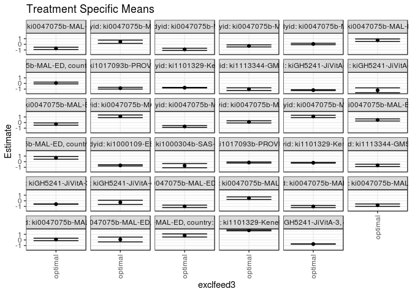

## Results Table

### Parameter: TSM

| agecat | studyid | country | intervention_level | baseline_level | estimate | ci_lower | ci_upper |
| --- | --- | --- | --- | --- | --- | --- | --- |
| Birth | ki0047075b-MAL-ED | BANGLADESH | optimal | observed | -0.9824783 | -1.1958133 | -0.7691432 |
| Birth | ki0047075b-MAL-ED | BRAZIL | optimal | observed | 0.4683104 | 0.2401520 | 0.6964688 |
| Birth | ki0047075b-MAL-ED | INDIA | optimal | observed | -1.0168090 | -1.2027344 | -0.8308836 |
| Birth | ki0047075b-MAL-ED | NEPAL | optimal | observed | -0.7815670 | -0.9963959 | -0.5667381 |
| Birth | ki0047075b-MAL-ED | PERU | optimal | observed | 0.0826549 | -0.1351791 | 0.3004889 |
| Birth | ki0047075b-MAL-ED | SOUTH AFRICA | optimal | observed | 0.0772687 | -0.3469162 | 0.5014537 |
| Birth | ki0047075b-MAL-ED | TANZANIA, UNITED REPUBLIC OF | optimal | observed | 0.7906021 | 0.5122667 | 1.0689375 |
| Birth | ki1101329-Keneba | GAMBIA | optimal | observed | 1.7074107 | 1.6175917 | 1.7972298 |
| Birth | kiGH5241-JiVitA-3 | BANGLADESH | optimal | observed | -0.7307797 | -0.7631823 | -0.6983770 |
| 6 months | ki0047075b-MAL-ED | BANGLADESH | optimal | observed | -0.2661469 | -0.4663835 | -0.0659102 |
| 6 months | ki0047075b-MAL-ED | BRAZIL | optimal | observed | 1.1101277 | 0.8733983 | 1.3468570 |
| 6 months | ki0047075b-MAL-ED | INDIA | optimal | observed | -0.6941637 | -0.8596199 | -0.5287075 |
| 6 months | ki0047075b-MAL-ED | NEPAL | optimal | observed | 0.1180116 | -0.0726169 | 0.3086400 |
| 6 months | ki0047075b-MAL-ED | PERU | optimal | observed | 1.0865667 | 0.8788151 | 1.2943183 |
| 6 months | ki0047075b-MAL-ED | SOUTH AFRICA | optimal | observed | 0.4668176 | 0.2774756 | 0.6561597 |
| 6 months | ki0047075b-MAL-ED | TANZANIA, UNITED REPUBLIC OF | optimal | observed | 0.6798414 | 0.4416075 | 0.9180753 |
| 6 months | ki1000109-EE | PAKISTAN | optimal | observed | -0.6549990 | -0.7694214 | -0.5405767 |
| 6 months | ki1000304b-SAS-CompFeed | INDIA | optimal | observed | -0.7024985 | -1.0772887 | -0.3277082 |
| 6 months | ki1017093b-PROVIDE | BANGLADESH | optimal | observed | -0.1467053 | -0.2431758 | -0.0502347 |
| 6 months | ki1101329-Keneba | GAMBIA | optimal | observed | -0.1910878 | -0.2533453 | -0.1288303 |
| 6 months | ki1113344-GMS-Nepal | NEPAL | optimal | observed | -0.6498464 | -0.8484701 | -0.4512226 |
| 6 months | kiGH5241-JiVitA-3 | BANGLADESH | optimal | observed | -0.5889197 | -0.6126969 | -0.5651425 |
| 6 months | kiGH5241-JiVitA-4 | BANGLADESH | optimal | observed | -0.2748220 | -0.6474148 | 0.0977709 |
| 24 months | ki0047075b-MAL-ED | BANGLADESH | optimal | observed | -0.7166369 | -0.9164536 | -0.5168202 |
| 24 months | ki0047075b-MAL-ED | BRAZIL | optimal | observed | 0.4663036 | 0.1777986 | 0.7548085 |
| 24 months | ki0047075b-MAL-ED | INDIA | optimal | observed | -0.8892775 | -1.0898249 | -0.6887300 |
| 24 months | ki0047075b-MAL-ED | NEPAL | optimal | observed | -0.2785211 | -0.4566640 | -0.1003783 |
| 24 months | ki0047075b-MAL-ED | PERU | optimal | observed | 0.0667432 | -0.0639188 | 0.1974051 |
| 24 months | ki0047075b-MAL-ED | SOUTH AFRICA | optimal | observed | 0.7366842 | 0.5160843 | 0.9572840 |
| 24 months | ki0047075b-MAL-ED | TANZANIA, UNITED REPUBLIC OF | optimal | observed | 0.0809258 | -0.0745243 | 0.2363759 |
| 24 months | ki1017093b-PROVIDE | BANGLADESH | optimal | observed | -0.8451745 | -1.0010918 | -0.6892573 |
| 24 months | ki1101329-Keneba | GAMBIA | optimal | observed | -0.7558971 | -0.8109670 | -0.7008271 |
| 24 months | ki1113344-GMS-Nepal | NEPAL | optimal | observed | -1.0135692 | -1.2504843 | -0.7766541 |
| 24 months | kiGH5241-JiVitA-3 | BANGLADESH | optimal | observed | -1.1862473 | -1.2563311 | -1.1161636 |
| 24 months | kiGH5241-JiVitA-4 | BANGLADESH | optimal | observed | -1.2167433 | -1.6534570 | -0.7800295 |

### Parameter: E(Y)

| agecat | studyid | country | intervention_level | baseline_level | estimate | ci_lower | ci_upper |
| --- | --- | --- | --- | --- | --- | --- | --- |
| Birth | ki0047075b-MAL-ED | BANGLADESH | observed | observed | -0.9701762 | -1.1093516 | -0.8310008 |
| Birth | ki0047075b-MAL-ED | BRAZIL | observed | observed | 0.3837288 | 0.2059602 | 0.5614974 |
| Birth | ki0047075b-MAL-ED | INDIA | observed | observed | -1.0824352 | -1.2259825 | -0.9388879 |
| Birth | ki0047075b-MAL-ED | NEPAL | observed | observed | -0.9184337 | -1.0582074 | -0.7786600 |
| Birth | ki0047075b-MAL-ED | PERU | observed | observed | -0.0558491 | -0.1687562 | 0.0570581 |
| Birth | ki0047075b-MAL-ED | SOUTH AFRICA | observed | observed | -0.0290476 | -0.1772448 | 0.1191495 |
| Birth | ki0047075b-MAL-ED | TANZANIA, UNITED REPUBLIC OF | observed | observed | 0.7865789 | 0.5832028 | 0.9899551 |
| Birth | ki1101329-Keneba | GAMBIA | observed | observed | 1.6646743 | 1.5791251 | 1.7502236 |
| Birth | kiGH5241-JiVitA-3 | BANGLADESH | observed | observed | -0.7222456 | -0.7423351 | -0.7021562 |
| 6 months | ki0047075b-MAL-ED | BANGLADESH | observed | observed | -0.1245816 | -0.2544517 | 0.0052886 |
| 6 months | ki0047075b-MAL-ED | BRAZIL | observed | observed | 0.9717225 | 0.8073791 | 1.1360658 |
| 6 months | ki0047075b-MAL-ED | INDIA | observed | observed | -0.7105222 | -0.8368775 | -0.5841669 |
| 6 months | ki0047075b-MAL-ED | NEPAL | observed | observed | 0.1010587 | -0.0308005 | 0.2329178 |
| 6 months | ki0047075b-MAL-ED | PERU | observed | observed | 1.0571296 | 0.9346064 | 1.1796528 |
| 6 months | ki0047075b-MAL-ED | SOUTH AFRICA | observed | observed | 0.5435551 | 0.3895443 | 0.6975659 |
| 6 months | ki0047075b-MAL-ED | TANZANIA, UNITED REPUBLIC OF | observed | observed | 0.5063403 | 0.3745918 | 0.6380888 |
| 6 months | ki1000109-EE | PAKISTAN | observed | observed | -0.7218667 | -0.8355727 | -0.6081607 |
| 6 months | ki1000304b-SAS-CompFeed | INDIA | observed | observed | -0.6348861 | -0.7630511 | -0.5067211 |
| 6 months | ki1017093b-PROVIDE | BANGLADESH | observed | observed | -0.2083706 | -0.2927992 | -0.1239419 |
| 6 months | ki1101329-Keneba | GAMBIA | observed | observed | -0.2057405 | -0.2614576 | -0.1500234 |
| 6 months | ki1113344-GMS-Nepal | NEPAL | observed | observed | -0.6194068 | -0.7173394 | -0.5214742 |
| 6 months | kiGH5241-JiVitA-3 | BANGLADESH | observed | observed | -0.5929896 | -0.6128338 | -0.5731455 |
| 6 months | kiGH5241-JiVitA-4 | BANGLADESH | observed | observed | -0.3657303 | -0.5647992 | -0.1666615 |
| 24 months | ki0047075b-MAL-ED | BANGLADESH | observed | observed | -0.8080769 | -0.9302432 | -0.6859106 |
| 24 months | ki0047075b-MAL-ED | BRAZIL | observed | observed | 0.4466272 | 0.2416144 | 0.6516401 |
| 24 months | ki0047075b-MAL-ED | INDIA | observed | observed | -0.9551111 | -1.0714034 | -0.8388188 |
| 24 months | ki0047075b-MAL-ED | NEPAL | observed | observed | -0.3795556 | -0.4938120 | -0.2652991 |
| 24 months | ki0047075b-MAL-ED | PERU | observed | observed | 0.1242714 | 0.0054301 | 0.2431126 |
| 24 months | ki0047075b-MAL-ED | SOUTH AFRICA | observed | observed | 0.4157543 | 0.2953789 | 0.5361297 |
| 24 months | ki0047075b-MAL-ED | TANZANIA, UNITED REPUBLIC OF | observed | observed | 0.0434286 | -0.0830724 | 0.1699295 |
| 24 months | ki1017093b-PROVIDE | BANGLADESH | observed | observed | -0.8879412 | -0.9708680 | -0.8050144 |
| 24 months | ki1101329-Keneba | GAMBIA | observed | observed | -0.7930925 | -0.8442611 | -0.7419240 |
| 24 months | ki1113344-GMS-Nepal | NEPAL | observed | observed | -1.1267450 | -1.2257791 | -1.0277110 |
| 24 months | kiGH5241-JiVitA-3 | BANGLADESH | observed | observed | -1.3031012 | -1.3269655 | -1.2792368 |
| 24 months | kiGH5241-JiVitA-4 | BANGLADESH | observed | observed | -1.0137086 | -1.1659964 | -0.8614208 |

### Parameter: PAR

| agecat | studyid | country | intervention_level | baseline_level | estimate | ci_lower | ci_upper |
| --- | --- | --- | --- | --- | --- | --- | --- |
| Birth | ki0047075b-MAL-ED | BANGLADESH | optimal | observed | 0.0123021 | -0.1252687 | 0.1498728 |
| Birth | ki0047075b-MAL-ED | BRAZIL | optimal | observed | -0.0845816 | -0.2067468 | 0.0375836 |
| Birth | ki0047075b-MAL-ED | INDIA | optimal | observed | -0.0656262 | -0.1741690 | 0.0429165 |
| Birth | ki0047075b-MAL-ED | NEPAL | optimal | observed | -0.1368667 | -0.3074489 | 0.0337154 |
| Birth | ki0047075b-MAL-ED | PERU | optimal | observed | -0.1385039 | -0.3341211 | 0.0571132 |
| Birth | ki0047075b-MAL-ED | SOUTH AFRICA | optimal | observed | -0.1063164 | -0.4997130 | 0.2870803 |
| Birth | ki0047075b-MAL-ED | TANZANIA, UNITED REPUBLIC OF | optimal | observed | -0.0040231 | -0.2077235 | 0.1996772 |
| Birth | ki1101329-Keneba | GAMBIA | optimal | observed | -0.0427364 | -0.0777658 | -0.0077069 |
| Birth | kiGH5241-JiVitA-3 | BANGLADESH | optimal | observed | 0.0085340 | -0.0145656 | 0.0316336 |
| 6 months | ki0047075b-MAL-ED | BANGLADESH | optimal | observed | 0.1415653 | 0.0025005 | 0.2806301 |
| 6 months | ki0047075b-MAL-ED | BRAZIL | optimal | observed | -0.1384052 | -0.3186016 | 0.0417912 |
| 6 months | ki0047075b-MAL-ED | INDIA | optimal | observed | -0.0163585 | -0.1405759 | 0.1078590 |
| 6 months | ki0047075b-MAL-ED | NEPAL | optimal | observed | -0.0169529 | -0.1725276 | 0.1386218 |
| 6 months | ki0047075b-MAL-ED | PERU | optimal | observed | -0.0294371 | -0.2098225 | 0.1509483 |
| 6 months | ki0047075b-MAL-ED | SOUTH AFRICA | optimal | observed | 0.0767375 | -0.0377047 | 0.1911797 |
| 6 months | ki0047075b-MAL-ED | TANZANIA, UNITED REPUBLIC OF | optimal | observed | -0.1735011 | -0.3623304 | 0.0153282 |
| 6 months | ki1000109-EE | PAKISTAN | optimal | observed | -0.0668676 | -0.1090553 | -0.0246799 |
| 6 months | ki1000304b-SAS-CompFeed | INDIA | optimal | observed | 0.0676124 | -0.3469319 | 0.4821567 |
| 6 months | ki1017093b-PROVIDE | BANGLADESH | optimal | observed | -0.0616653 | -0.1187157 | -0.0046150 |
| 6 months | ki1101329-Keneba | GAMBIA | optimal | observed | -0.0146527 | -0.0454259 | 0.0161204 |
| 6 months | ki1113344-GMS-Nepal | NEPAL | optimal | observed | 0.0304395 | -0.1409586 | 0.2018377 |
| 6 months | kiGH5241-JiVitA-3 | BANGLADESH | optimal | observed | -0.0040699 | -0.0170932 | 0.0089534 |
| 6 months | kiGH5241-JiVitA-4 | BANGLADESH | optimal | observed | -0.0909084 | -0.4440099 | 0.2621932 |
| 24 months | ki0047075b-MAL-ED | BANGLADESH | optimal | observed | -0.0914400 | -0.2580944 | 0.0752143 |
| 24 months | ki0047075b-MAL-ED | BRAZIL | optimal | observed | -0.0196764 | -0.1969511 | 0.1575984 |
| 24 months | ki0047075b-MAL-ED | INDIA | optimal | observed | -0.0658337 | -0.2011494 | 0.0694821 |
| 24 months | ki0047075b-MAL-ED | NEPAL | optimal | observed | -0.1010344 | -0.2421116 | 0.0400427 |
| 24 months | ki0047075b-MAL-ED | PERU | optimal | observed | 0.0575282 | -0.0372103 | 0.1522667 |
| 24 months | ki0047075b-MAL-ED | SOUTH AFRICA | optimal | observed | -0.3209299 | -0.5366038 | -0.1052560 |
| 24 months | ki0047075b-MAL-ED | TANZANIA, UNITED REPUBLIC OF | optimal | observed | -0.0374972 | -0.1107936 | 0.0357992 |
| 24 months | ki1017093b-PROVIDE | BANGLADESH | optimal | observed | -0.0427667 | -0.1713515 | 0.0858182 |
| 24 months | ki1101329-Keneba | GAMBIA | optimal | observed | -0.0371955 | -0.0579776 | -0.0164133 |
| 24 months | ki1113344-GMS-Nepal | NEPAL | optimal | observed | -0.1131758 | -0.3340073 | 0.1076556 |
| 24 months | kiGH5241-JiVitA-3 | BANGLADESH | optimal | observed | -0.1168538 | -0.1830229 | -0.0506847 |
| 24 months | kiGH5241-JiVitA-4 | BANGLADESH | optimal | observed | 0.2030347 | -0.2089233 | 0.6149926 |